# Part I: Teaching Strategy

February 27, 2020

## Purpose

Outline strategies for teaching the requested topic, **sampling distribution of the sample mean**.

Time: \(\leq\) 30 min

## Prerequisite Knowledge

Prerequisite knowledge that students would be expected to know:

- Sampling from a population (distribution) in R.
- Multi-step simulations.
- How to interpret and calculate mean and quantiles, both empirical and true.
- Conceptually build and read a histogram, but not necessarily know how to make one.
- The concept of a sample/empirical mean vs. the true mean, and the LLN.
  - We’ve so far put aside the question of “how good” the sample mean is when estimating the true mean.

## Learning Outcomes

Some learning outcomes might be:

- Define a sampling distribution, particularly pointing out the difference between a population distribution.
- Generate a sample from a sampling distribution of the mean, given a population distribution.
- Construct confidence intervals from a given sampling distribution of the mean to describe how well the empirical mean estimates the true mean.

## Difficulties

Some difficulties students might have learning the topic:

- In simulation: sample size vs. number of iterations.
- Identifying a transformation of random variables as having a distribution.
- Differentiating between sampling distribution and population distribution.
- Interpreting confidence intervals.

## Student Engagement and Learning

How you would engage the students with the topic? How would you assist them in attaining your learning outcomes?

## Live coding

Students have a worksheet during class. Example:

- Simulate from the sampling distribution of the mean of 5 draws from an Exp(1) distribution, using 1000 iterations.

```
map(1:FILL_THIS_IN, rexp, n = FILL_THIS_IN, rate = 1) %>%
    map_dbl(FILL_THIS_IN)
```

## Simulation

The topic of sampling distributions lends itself particularly well to simulation. I might ask:

1. Use R to generate a sample from the population distribution, and calculate the sample mean.
2. Submit your sample mean to a Google Form.

## In-class exercises

I’ll ask students to try an activity on their own, usually for about a minute, and then regroup.

Example:

1. Suppose N(5,5) is a sampling distribution for a mean of 10 observations. What is a 95% confidence interval for the mean?
2. Suppose N(5,5) is a population distribution for a mean of 10 observations. What is a 95% confidence interval for the mean?

## Think-Pair-Share

True or false:

1. If E(*X*) = *m*, then the sampling distribution is the distribution of *m*.
2. It’s impossible for the sampling distribution of the mean to have larger variance than the population distribution.
3. The sampling distribution of the mean of 10 observations is the same as the sampling distribution of the mean of 20 observations.

## Technology

What learning technologies can assist in the learning of the topic?

- Slack:
  - Discussion boards amongst students and teaching team.
  - Quick polls in-class
- Google forms: allows students to submit information.
- R + RStudio, or python + JupyterLab for in-class worksheets.
- Bookdown for lecture notes
- Github for hosting course content and making announcements.

## Assessment

How would you assess students’ attainment of your learning outcomes for this topic?

## Formative

Formative assessments include:

- Think-pair-share
- Checking in with each student during lab
- Office hours (especially open lecture-style)

## Summative: Quizzes

Here are a couple examples of quiz questions.

1. Consider the two distributions below. One of them is a population distribution, and the other is a sampling distribution of a mean of an iid sample. Which one is the sampling distribution?

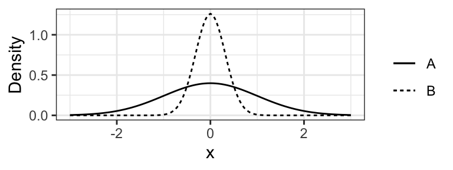

1. Why is it impossible for the sampling distribution of the mean (of an iid sample) to have a larger variance than the population distribution? Answer using no more than two **brief** sentences.

## Summative: Lab Assignments

An example question might be:

Consider the `octane.csv` data set, containing 25 purity measurements.

1. Plot the sampling distribution of the mean using both bootstrap and asymptotics.
2. Obtain 95% confidence intervals using both bootstrap and asymptotic distribution.